# Two-Period Semiparametric DID

Semiparametric two-period DID estimators target the period-1 ATT. The design uses high-dimensional sparse covariates, a sparse propensity score, and two periods of potential outcomes. The target is the period-1 ATT,

$$\tau_{ATT} = \mathbb{E}[Y^1(1) - Y^0(1) \mid D=1].$$

The comparison covers the usual two-period DID estimator together with outcome-modeling, IPW, and AIPW variants under two regimes:

- $\rho = 0$: unconditional parallel trends holds;
- $\rho = 2$: unconditional parallel trends fails, but conditional parallel trends holds after adjusting for $X$ through the propensity-index component in the untreated trend.

The nuisance fits use lightweight ridge/logistic-ridge learners so the page is self-contained in the Python docs environment. The estimator menu includes unadjusted DID, outcome-model DID, IPW DID, and AIPW DID, with plug-in and cross-fit versions of the nuisance-based estimators.

## 1 Imports And Helpers

```python
from html import escape

import matplotlib.pyplot as plt
import numpy as np
from IPython.display import HTML, display

np.set_printoptions(precision=4, suppress=True)


def html_table(headers, rows):
    parts = ["<table>", "<thead>", "<tr>"]
    parts.extend(f"<th>{escape(str(h))}</th>" for h in headers)
    parts.extend(["</tr>", "</thead>", "<tbody>"])
    for row in rows:
        parts.append("<tr>")
        parts.extend(f"<td>{cell}</td>" for cell in row)
        parts.append("</tr>")
    parts.extend(["</tbody>", "</table>"])
    return "".join(parts)


def expit(z):
    z = np.clip(z, -35.0, 35.0)
    return 1.0 / (1.0 + np.exp(-z))


def add_intercept(x):
    return np.column_stack([np.ones(x.shape[0]), x])


def make_folds(n, k, rng):
    idx = rng.permutation(n)
    return [fold for fold in np.array_split(idx, k) if fold.size]
```

## 2 DGP

Let $N=200$, $p=100$, and $s=5$. The covariates are

$$X_i \sim \mathcal{N}(0, I_p),$$

Treatment is assigned by

$$D_i \sim \mathrm{Bernoulli}(e_i),
\qquad
e_i = \Lambda(X_i^\top \gamma_0).$$

The potential outcomes are

$$\begin{aligned}
Y_i^0(0) &= X_i^\top \beta_0 + \varepsilon_i, \\
Y_i^0(1) &= Y_i^0(0) + 1 + \rho e_i + \varepsilon_i, \\
Y_i^1(1) &= \theta_0 + Y_i^0(1) + \varepsilon_i,
\end{aligned}$$

where $\beta_0 = \gamma_0 + 0.5$, $\theta_0 = 3$, and $\varepsilon_i \sim \mathcal{N}(0, 0.1^2)$. A common shock is used across the baseline, untreated-trend, and treated-outcome equations. The observed outcomes are $Y_i(0)=Y_i^0(0)$ and

$$Y_i(1) = (1-D_i)Y_i^0(1) + D_iY_i^1(1).$$

When $\rho = 0$, the untreated trend does not depend on the propensity score and the simple DID contrast is valid. When $\rho \neq 0$, units with high treatment probability also have different untreated trends, so unconditional DID is biased unless the covariates are accounted for.

```python
def semipar_did_dgp(n=200, p=100, s=5, theta=3.0, rho=0.0, rng=None):
    rng = np.random.default_rng() if rng is None else rng
    gamma = np.r_[np.arange(s, 0, -1) / s, np.zeros(p - s)]
    x = rng.normal(size=(n, p))
    e = expit(x @ gamma)
    d = rng.binomial(1, e, size=n).astype(float)
    beta = gamma + 0.5
    eps = rng.normal(0.0, 0.1, size=n)

    y00 = x @ beta + eps
    y01 = y00 + 1.0 + rho * e + eps
    y11 = theta + y01 + eps

    y0 = y00
    y1 = y01 * (1.0 - d) + y11 * d
    return {"y1": y1, "y0": y0, "d": d, "x": x, "e": e, "theta": theta, "rho": rho}


example = semipar_did_dgp(rho=2.0, rng=np.random.default_rng(42))
display(
    HTML(
        html_table(
            ["Quantity", "Value"],
            [
                ["N", example["x"].shape[0]],
                ["p", example["x"].shape[1]],
                ["Treated share", f"{example['d'].mean():.3f}"],
                ["Mean propensity", f"{example['e'].mean():.3f}"],
                ["True ATT", f"{example['theta']:.3f}"],
            ],
        )
    )
)
```

| Quantity | Value |
| --- | --- |
| N | 200 |
| p | 100 |
| Treated share | 0.475 |
| Mean propensity | 0.533 |
| True ATT | 3.000 |

## 3 Estimators

The comparison covers eight estimators:

1. `naive`: post-period treated-control difference;
2. `did`: unadjusted two-period DID;
3. `om`: outcome-model DID using fitted $\mathbb{E}[Y_t \mid X,D=d]$ surfaces;
4. `omXF`: cross-fit version of `om`;
5. `ipw`: Abadie-style IPW DID using a fitted propensity score;
6. `ipwXF`: cross-fit version of `ipw`;
7. `aipw`: double-robust DID using a propensity score and untreated-trend model;
8. `aipwXF`: cross-fit version of `aipw`.

The estimating equations are easiest to see after defining $\Delta Y_i = Y_i(1)-Y_i(0)$ and $\hat p = n^{-1}\sum_i D_i$. The IPW score is

$$\hat\tau^{IPW}
= \frac{1}{n}\sum_i
\frac{D_i - \hat e(X_i)}{\hat p(1-\hat e(X_i))}\Delta Y_i.$$

The AIPW score subtracts the untreated-trend model $\hat m_0(X_i) \approx \mathbb{E}[\Delta Y_i \mid X_i, D_i=0]$ before applying the same balancing score:

$$\hat\tau^{AIPW}
= \frac{1}{n}\sum_i
\frac{D_i - \hat e(X_i)}{\hat p(1-\hat e(X_i))}
\{\Delta Y_i - \hat m_0(X_i)\}.$$

```python
def ridge_fit(x, y, penalty=1.0):
    z = add_intercept(x)
    gram = z.T @ z
    ridge = np.eye(gram.shape[0]) * penalty
    ridge[0, 0] = 0.0
    return np.linalg.solve(gram + ridge, z.T @ y)


def ridge_predict(x, beta):
    return add_intercept(x) @ beta


def logistic_ridge_fit(x, y, penalty=1.0, max_iter=40):
    z = add_intercept(x)
    beta = np.zeros(z.shape[1])
    ridge = np.eye(z.shape[1]) * penalty
    ridge[0, 0] = 0.0
    for _ in range(max_iter):
        eta = z @ beta
        p = expit(eta)
        w = np.clip(p * (1.0 - p), 1e-5, None)
        grad = z.T @ (p - y) + ridge @ beta
        hess = z.T @ (z * w[:, None]) + ridge
        step = np.linalg.solve(hess, grad)
        beta -= step
        if np.max(np.abs(step)) < 1e-6:
            break
    return beta


def logistic_predict(x, beta, clip=0.02):
    return np.clip(expit(add_intercept(x) @ beta), clip, 1.0 - clip)


def crossfit_predict(x, y, fit_fn, pred_fn, penalty, k, rng, subset=None):
    n = x.shape[0]
    pred = np.zeros(n)
    if subset is None:
        subset = np.arange(n)
    subset = np.asarray(subset)
    folds = make_folds(subset.size, k, rng)
    for fold in folds:
        test = subset[fold]
        train = np.setdiff1d(subset, test, assume_unique=False)
        beta = fit_fn(x[train], y[train], penalty)
        pred[test] = pred_fn(x[test], beta)
    return pred


def two_period_did(d, y1, y0):
    return (y1[d == 1].mean() - y0[d == 1].mean()) - (y1[d == 0].mean() - y0[d == 0].mean())


def om_did(x, d, y1, y0, xfit=False, penalty=1.0, rng=None):
    rng = np.random.default_rng(0) if rng is None else rng
    treated = np.flatnonzero(d == 1.0)
    control = np.flatnonzero(d == 0.0)
    preds = []
    for y, group in [(y1, treated), (y1, control), (y0, treated), (y0, control)]:
        beta = ridge_fit(x[group], y[group], penalty)
        pred = ridge_predict(x, beta)
        if xfit:
            pred[group] = crossfit_predict(x, y, ridge_fit, ridge_predict, penalty, 3, rng, subset=group)[group]
        preds.append(pred)
    m1, m2, m3, m4 = preds
    return float(np.mean((m1 - m2) - (m3 - m4)))


def propensity_hat(x, d, xfit=False, penalty=1.0, rng=None):
    if not xfit:
        beta = logistic_ridge_fit(x, d, penalty)
        return logistic_predict(x, beta)
    rng = np.random.default_rng(0) if rng is None else rng
    return crossfit_predict(x, d, logistic_ridge_fit, logistic_predict, penalty, 3, rng)


def ipw_did(x, d, y1, y0, xfit=False, penalty=1.0, rng=None):
    ehat = propensity_hat(x, d, xfit=xfit, penalty=penalty, rng=rng)
    delta = y1 - y0
    score = (d - ehat) / (d.mean() * (1.0 - ehat))
    return float(np.mean(score * delta))


def aipw_did(x, d, y1, y0, xfit=False, penalty=1.0, rng=None):
    rng = np.random.default_rng(0) if rng is None else rng
    ehat = propensity_hat(x, d, xfit=xfit, penalty=penalty, rng=rng)
    delta = y1 - y0
    control = np.flatnonzero(d == 0.0)
    beta = ridge_fit(x[control], delta[control], penalty)
    mhat = ridge_predict(x, beta)
    if xfit:
        mhat[control] = crossfit_predict(x, delta, ridge_fit, ridge_predict, penalty, 3, rng, subset=control)[control]
    score = (d - ehat) / (d.mean() * (1.0 - ehat))
    return float(np.mean(score * (delta - mhat)))


def estimate_all(draw, penalty=25.0, rng=None):
    y1, y0, d, x = draw["y1"], draw["y0"], draw["d"], draw["x"]
    rng = np.random.default_rng(0) if rng is None else rng
    return {
        "naive": float(y1[d == 1].mean() - y1[d == 0].mean()),
        "did": two_period_did(d, y1, y0),
        "om": om_did(x, d, y1, y0, xfit=False, penalty=penalty, rng=rng),
        "omXF": om_did(x, d, y1, y0, xfit=True, penalty=penalty, rng=rng),
        "ipw": ipw_did(x, d, y1, y0, xfit=False, penalty=penalty, rng=rng),
        "ipwXF": ipw_did(x, d, y1, y0, xfit=True, penalty=penalty, rng=rng),
        "aipw": aipw_did(x, d, y1, y0, xfit=False, penalty=penalty, rng=rng),
        "aipwXF": aipw_did(x, d, y1, y0, xfit=True, penalty=penalty, rng=rng),
    }


trial = estimate_all(semipar_did_dgp(rho=0.0, rng=np.random.default_rng(7)), rng=np.random.default_rng(8))
display(HTML(html_table(["Estimator", "Estimate"], [[k, f"{v:.3f}"] for k, v in trial.items()])))
```

| Estimator | Estimate |
| --- | --- |
| naive | 5.252 |
| did | 3.015 |
| om | 3.003 |
| omXF | 3.201 |
| ipw | 3.445 |
| ipwXF | 2.784 |
| aipw | 3.028 |
| aipwXF | 3.033 |

## 4 Monte Carlo

The simulation compares $\rho=0$ and $\rho=2$. The true effect is $\theta_0=3$ in both cases.

```python
def summarize(vals, truth):
    vals = np.asarray(vals)
    err = vals - truth
    return {
        "mean": float(vals.mean()),
        "bias": float(err.mean()),
        "mab": float(abs(err.mean())),
        "sd": float(vals.std(ddof=1)),
        "mse": float(np.mean(err**2)),
    }


def run_mc(rhos=(0.0, 2.0), reps=150, seed=20260516):
    rng = np.random.default_rng(seed)
    rows = []
    draws = {rho: {name: [] for name in ["naive", "did", "om", "omXF", "ipw", "ipwXF", "aipw", "aipwXF"]} for rho in rhos}
    for rho in rhos:
        for _ in range(reps):
            draw = semipar_did_dgp(rho=rho, rng=rng)
            est = estimate_all(draw, penalty=25.0, rng=rng)
            for name, value in est.items():
                draws[rho][name].append(value)
        for name, vals in draws[rho].items():
            rows.append({"rho": rho, "estimator": name, **summarize(vals, 3.0)})
    return rows, draws


mc_rows, mc_draws = run_mc()

for rho in [0.0, 2.0]:
    display(HTML(f"<h4>rho = {rho:g}</h4>"))
    display(
        HTML(
            html_table(
                ["Estimator", "Mean", "Bias", "Mean Absolute Bias", "SD", "MSE"],
                [
                    [
                        r["estimator"],
                        f"{r['mean']:.3f}",
                        f"{r['bias']:+.3f}",
                        f"{r['mab']:.3f}",
                        f"{r['sd']:.3f}",
                        f"{r['mse']:.3f}",
                    ]
                    for r in mc_rows
                    if r["rho"] == rho
                ],
            )
        )
    )
```

rho = 0

| Estimator | Mean | Bias | Mean Absolute Bias | SD | MSE |
| --- | --- | --- | --- | --- | --- |
| naive | 5.601 | +2.601 | 2.601 | 0.777 | 7.366 |
| did | 3.002 | +0.002 | 0.002 | 0.021 | 0.000 |
| om | 3.002 | +0.002 | 0.002 | 0.026 | 0.001 |
| omXF | 3.014 | +0.014 | 0.014 | 0.210 | 0.044 |
| ipw | 3.476 | +0.476 | 0.476 | 0.053 | 0.229 |
| ipwXF | 2.768 | -0.232 | 0.232 | 0.186 | 0.088 |
| aipw | 3.004 | +0.004 | 0.004 | 0.026 | 0.001 |
| aipwXF | 3.006 | +0.006 | 0.006 | 0.033 | 0.001 |

rho = 2

| Estimator | Mean | Bias | Mean Absolute Bias | SD | MSE |
| --- | --- | --- | --- | --- | --- |
| naive | 6.124 | +3.124 | 3.124 | 0.812 | 10.412 |
| did | 3.590 | +0.590 | 0.590 | 0.070 | 0.352 |
| om | 3.301 | +0.301 | 0.301 | 0.055 | 0.094 |
| omXF | 3.292 | +0.292 | 0.292 | 0.188 | 0.120 |
| ipw | 4.304 | +1.304 | 1.304 | 0.141 | 1.721 |
| ipwXF | 2.929 | -0.071 | 0.071 | 0.372 | 0.142 |
| aipw | 3.273 | +0.273 | 0.273 | 0.064 | 0.079 |
| aipwXF | 3.106 | +0.106 | 0.106 | 0.099 | 0.021 |

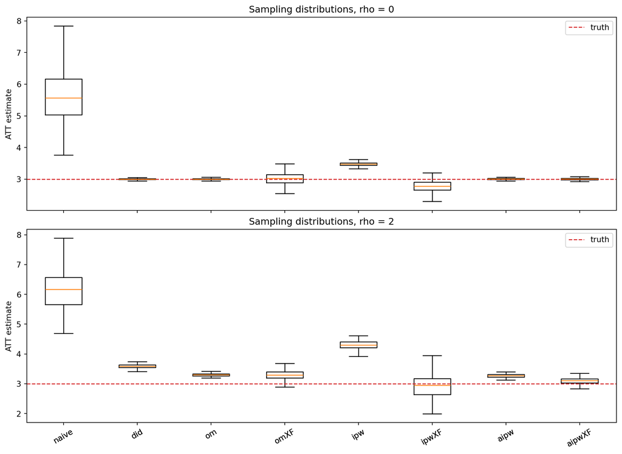

```python
fig, axes = plt.subplots(2, 1, figsize=(11, 8), constrained_layout=True, sharex=True)
order = ["naive", "did", "om", "omXF", "ipw", "ipwXF", "aipw", "aipwXF"]
for ax, rho in zip(axes, [0.0, 2.0]):
    data = [mc_draws[rho][name] for name in order]
    ax.boxplot(data, labels=order, showfliers=False)
    ax.axhline(3.0, color="tab:red", linestyle="--", linewidth=1.2, label="truth")
    ax.set_title(f"Sampling distributions, rho = {rho:g}")
    ax.set_ylabel("ATT estimate")
    ax.legend(loc="upper right")
axes[-1].tick_params(axis="x", rotation=30)
plt.show()
```

## 5 Reading The Results

When $\rho=0$, unconditional parallel trends holds. The unadjusted DID estimator is therefore centered near the true effect, while the post-period naive contrast remains badly confounded because treated and control units differ in the sparse propensity-index covariates.

The cross-fit columns avoid using each observation’s own outcome to construct its nuisance prediction. In this small-$N$, high-$p$ design, cross-fitting is not guaranteed to reduce variance in every estimator, but it is the safer pattern for the doubly robust score.